# Homework 5

Karan Kurani

2023-10-11

## Loading Libraries

```r
library(tidyverse)
library(moderndive)
library(skimr)
library(ISLR)
```

## Data Manipulation

```r
evals <- evals %>%
  select(ID, score, age, gender)

glimpse(evals)
```

```
## Rows: 463
## Columns: 4
## $ ID     <int> 1, 2, 3, 4, 5, 6, 7, 8, 9, 10, 11, 12, 13, 14, 15, 16, 17, 18, …
## $ score  <dbl> 4.7, 4.1, 3.9, 4.8, 4.6, 4.3, 2.8, 4.1, 3.4, 4.5, 3.8, 4.5, 4.6…
## $ age    <int> 36, 36, 36, 36, 59, 59, 59, 51, 51, 40, 40, 40, 40, 40, 40, 40,…
## $ gender <fct> female, female, female, female, male, male, male, male, male, f…
```

```r
evals %>% sample_n(size = 5)
```

```
## # A tibble: 5 × 4
##      ID score   age gender
##   <int> <dbl> <int> <fct>
## 1   447   3.7    60 female
## 2    10   4.5    40 female
## 3   328   3.5    64 male
## 4   383   4.7    43 male
## 5    86   4.4    45 male
```

```r
evals %>% select(score, age, gender) %>% skim()
```

Data summary

| Name | Piped data |
| --- | --- |
| Number of rows | 463 |
| Number of columns | 3 |
| _______________________ |  |
| Column type frequency: |  |
| factor | 1 |
| numeric | 2 |
| ________________________ |  |
| Group variables | None |

**Variable type: factor**

| skim_variable | n_missing | complete_rate | ordered | n_unique | top_counts |
| --- | --- | --- | --- | --- | --- |
| gender | 0 | 1 | FALSE | 2 | mal: 268, fem: 195 |

**Variable type: numeric**

| skim_variable | n_missing | complete_rate | mean | sd | p0 | p25 | p50 | p75 | p100 | hist |
| --- | --- | --- | --- | --- | --- | --- | --- | --- | --- | --- |
| score | 0 | 1 | 4.17 | 0.54 | 2.3 | 3.8 | 4.3 | 4.6 | 5 | ▁▁▅▇▇ |
| age | 0 | 1 | 48.37 | 9.80 | 29.0 | 42.0 | 48.0 | 57.0 | 73 | ▅▆▇▆▁ |

## Exploratory Analysis

```r
evals %>%
  get_correlation(formula = score ~ age)
```

```
## # A tibble: 1 × 1
##      cor
##    <dbl>
## 1 -0.107
```

## Visual Exploration

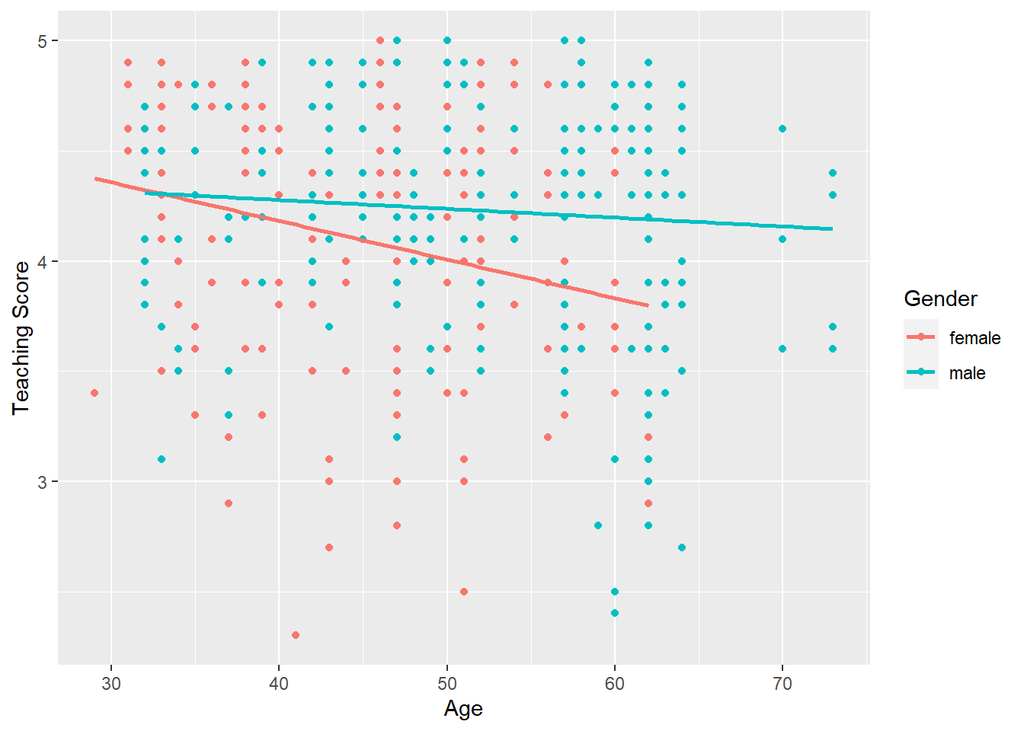

```r
ggplot(evals, aes(x = age, y = score, color = gender)) +
  geom_point() +
  labs(x = "Age", y = "Teaching Score", color = "Gender") +
  geom_smooth(method = "lm", se = FALSE)
```

## Model Creation and Summary

```r
score_model_interaction <- lm(score ~ age * gender, data = evals)
get_regression_table(score_model_interaction)
```

```
## # A tibble: 4 × 7
##   term           estimate std_error statistic p_value lower_ci upper_ci
##   <chr>             <dbl>     <dbl>     <dbl>   <dbl>    <dbl>    <dbl>
## 1 intercept         4.88      0.205     23.8    0        4.48     5.29
## 2 age              -0.018     0.004     -3.92   0       -0.026   -0.009
## 3 gender: male     -0.446     0.265     -1.68   0.094   -0.968    0.076
## 4 age:gendermale    0.014     0.006      2.45   0.015    0.003    0.024
```

## Visualization of Parallel Slopes

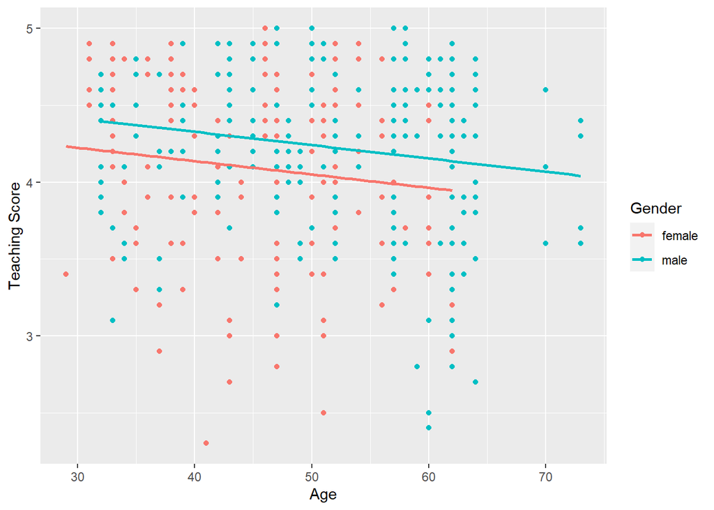

```r
ggplot(evals, aes(x = age, y = score, color = gender)) +
  geom_point() +
  labs(x = "Age", y = "Teaching Score", color = "Gender") +
  geom_parallel_slopes(se = FALSE)
```

## Parallel Slopes Model Creation and Summary

```r
score_model_parallel_slopes <- lm(score ~ age + gender, data = evals)
get_regression_table(score_model_parallel_slopes)
```

```
## # A tibble: 3 × 7
##   term         estimate std_error statistic p_value lower_ci upper_ci
##   <chr>           <dbl>     <dbl>     <dbl>   <dbl>    <dbl>    <dbl>
## 1 intercept       4.48      0.125     35.8    0        4.24     4.73
## 2 age            -0.009     0.003     -3.28   0.001   -0.014   -0.003
## 3 gender: male    0.191     0.052      3.63   0        0.087    0.294
```

## Regression Points

```r
regression_points <- get_regression_points(score_model_interaction)
regression_points
```

```
## # A tibble: 463 × 6
##       ID score   age gender score_hat residual
##    <int> <dbl> <int> <fct>      <dbl>    <dbl>
##  1     1   4.7    36 female      4.25    0.448
##  2     2   4.1    36 female      4.25   -0.152
##  3     3   3.9    36 female      4.25   -0.352
##  4     4   4.8    36 female      4.25    0.548
##  5     5   4.6    59 male        4.20    0.399
##  6     6   4.3    59 male        4.20    0.099
##  7     7   2.8    59 male        4.20   -1.40
##  8     8   4.1    51 male        4.23   -0.133
##  9     9   3.4    51 male        4.23   -0.833
## 10    10   4.5    40 female      4.18    0.318
## # ℹ 453 more rows
```

# Transform Credit dataset

```r
library(ISLR)
credit <- Credit %>% as_tibble() %>%
  select(ID, debt = Balance, credit_limit = Limit,
         income = Income, credit_rating = Rating, age = Age)
```

# Get a glimpse of the data

```r
glimpse(credit)
```

```
## Rows: 400
## Columns: 6
## $ ID            <int> 1, 2, 3, 4, 5, 6, 7, 8, 9, 10, 11, 12, 13, 14, 15, 16, 1…
## $ debt          <int> 333, 903, 580, 964, 331, 1151, 203, 872, 279, 1350, 1407…
## $ credit_limit  <int> 3606, 6645, 7075, 9504, 4897, 8047, 3388, 7114, 3300, 68…
## $ income        <dbl> 14.891, 106.025, 104.593, 148.924, 55.882, 80.180, 20.99…
## $ credit_rating <int> 283, 483, 514, 681, 357, 569, 259, 512, 266, 491, 589, 1…
## $ age           <int> 34, 82, 71, 36, 68, 77, 37, 87, 66, 41, 30, 64, 57, 49, …
```

```r
credit %>% sample_n(size = 5)
```

```
## # A tibble: 5 × 6
##      ID  debt credit_limit income credit_rating   age
##   <int> <int>        <int>  <dbl>         <int> <int>
## 1   248     0         2220   36.4           188    50
## 2   145    68         2748   17.4           228    32
## 3   137    75         4116   54.7           314    70
## 4   393     0         2308   26.0           196    24
## 5   362   382         4943   53.2           362    46
```

```r
credit %>% select(debt, credit_limit, income) %>% skim()
```

Data summary

| Name | Piped data |
| --- | --- |
| Number of rows | 400 |
| Number of columns | 3 |
| _______________________ |  |
| Column type frequency: |  |
| numeric | 3 |
| ________________________ |  |
| Group variables | None |

**Variable type: numeric**

| skim_variable | n_missing | complete_rate | mean | sd | p0 | p25 | p50 | p75 | p100 | hist |
| --- | --- | --- | --- | --- | --- | --- | --- | --- | --- | --- |
| debt | 0 | 1 | 520.02 | 459.76 | 0.00 | 68.75 | 459.50 | 863.00 | 1999.00 | ▇▅▃▂▁ |
| credit_limit | 0 | 1 | 4735.60 | 2308.20 | 855.00 | 3088.00 | 4622.50 | 5872.75 | 13913.00 | ▆▇▃▁▁ |
| income | 0 | 1 | 45.22 | 35.24 | 10.35 | 21.01 | 33.12 | 57.47 | 186.63 | ▇▂▁▁▁ |

```r
# Correlation analysis
credit %>% get_correlation(debt ~ credit_limit)
```

```
## # A tibble: 1 × 1
##     cor
##   <dbl>
## 1 0.862
```

```r
credit %>% get_correlation(debt ~ income)
```

```
## # A tibble: 1 × 1
##     cor
##   <dbl>
## 1 0.464
```

```r
credit %>% select(debt, credit_limit, income) %>% cor()
```

```
##                   debt credit_limit    income
## debt         1.0000000    0.8616973 0.4636565
## credit_limit 0.8616973    1.0000000 0.7920883
## income       0.4636565    0.7920883 1.0000000
```

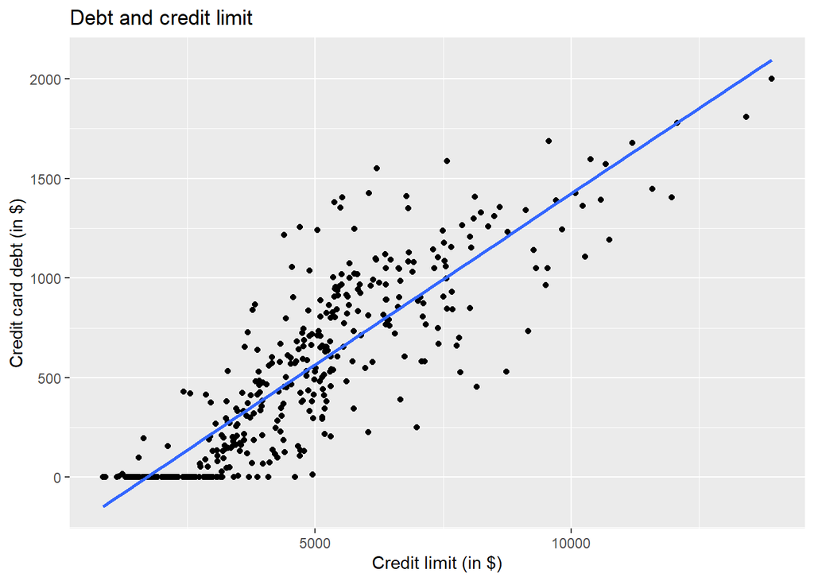

```r
# Visualizations
ggplot(credit, aes(x = credit_limit, y = debt)) +
  geom_point() +
  labs(x = "Credit limit (in $)", y = "Credit card debt (in $)", title = "Debt and credit limit") +
  geom_smooth(method = "lm", se = FALSE)
```

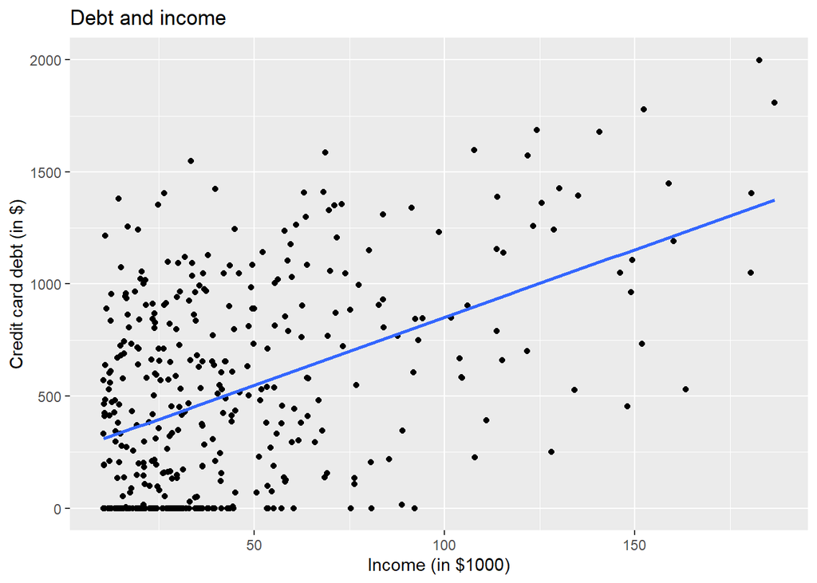

```r
ggplot(credit, aes(x = income, y = debt)) +
  geom_point() +
  labs(x = "Income (in $1000)", y = "Credit card debt (in $)", title = "Debt and income") +
  geom_smooth(method = "lm", se = FALSE)
```

```r
# Regression Model
debt_model <- lm(debt ~ credit_limit + income, data = credit)
get_regression_table(debt_model)
```

```
## # A tibble: 3 × 7
##   term         estimate std_error statistic p_value lower_ci upper_ci
##   <chr>           <dbl>     <dbl>     <dbl>   <dbl>    <dbl>    <dbl>
## 1 intercept    -385.       19.5       -19.8       0 -423.    -347.
## 2 credit_limit    0.264     0.006      45.0       0    0.253    0.276
## 3 income         -7.66      0.385     -19.9       0   -8.42    -6.91
```

```r
get_regression_points(debt_model)
```

```
## # A tibble: 400 × 6
##       ID  debt credit_limit income debt_hat residual
##    <int> <int>        <int>  <dbl>    <dbl>    <dbl>
##  1     1   333         3606   14.9     454.   -121.
##  2     2   903         6645  106.      559.    344.
##  3     3   580         7075  105.      683.   -103.
##  4     4   964         9504  149.      986.    -21.7
##  5     5   331         4897   55.9     481.   -150.
##  6     6  1151         8047   80.2    1127.     23.6
##  7     7   203         3388   21.0     349.   -146.
##  8     8   872         7114   71.4     948.    -76.0
##  9     9   279         3300   15.1     371.    -92.2
## 10    10  1350         6819   71.1     873.    477.
## # ℹ 390 more rows
```

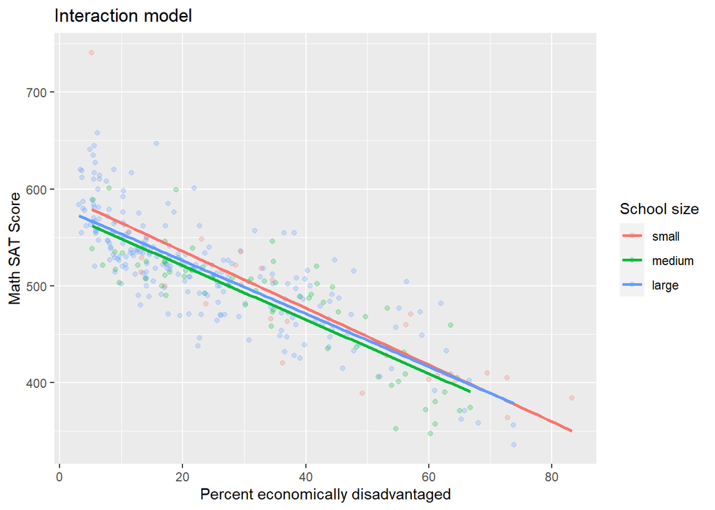

```r
# Visualizations
ggplot(MA_schools, aes(x = perc_disadvan, y = average_sat_math, color = size)) +
  geom_point(alpha = 0.25) +
  geom_smooth(method = "lm", se = FALSE) +
  labs(x = "Percent economically disadvantaged", y = "Math SAT Score", color = "School size", title = "Interaction model")
```

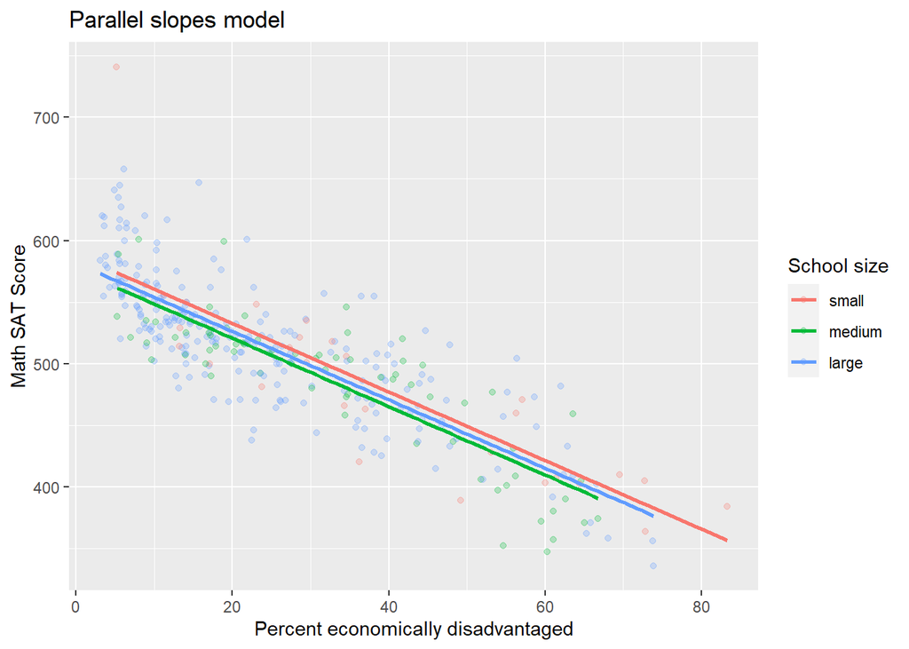

```r
ggplot(MA_schools, aes(x = perc_disadvan, y = average_sat_math, color = size)) +
  geom_point(alpha = 0.25) +
  geom_parallel_slopes(se = FALSE) +
  labs(x = "Percent economically disadvantaged", y = "Math SAT Score", color = "School size", title = "Parallel slopes model")
```

```r
# Regression Models
model_2_interaction <- lm(average_sat_math ~ perc_disadvan * size, data = MA_schools)
get_regression_table(model_2_interaction)
```

```
## # A tibble: 6 × 7
##   term                    estimate std_error statistic p_value lower_ci upper_ci
##   <chr>                      <dbl>     <dbl>     <dbl>   <dbl>    <dbl>    <dbl>
## 1 intercept                594.       13.3      44.7     0      568.     620.
## 2 perc_disadvan             -2.93      0.294    -9.96    0       -3.51    -2.35
## 3 size: medium             -17.8      15.8      -1.12    0.263  -48.9     13.4
## 4 size: large              -13.3      13.8      -0.962   0.337  -40.5     13.9
## 5 perc_disadvan:sizemedi…    0.146     0.371     0.393   0.694   -0.585    0.877
## 6 perc_disadvan:sizelarge    0.189     0.323     0.586   0.559   -0.446    0.824
```

```r
model_2_parallel_slopes <- lm(average_sat_math ~ perc_disadvan + size, data = MA_schools)
get_regression_table(model_2_parallel_slopes)
```

```
## # A tibble: 4 × 7
##   term          estimate std_error statistic p_value lower_ci upper_ci
##   <chr>            <dbl>     <dbl>     <dbl>   <dbl>    <dbl>    <dbl>
## 1 intercept       588.       7.61     77.3     0       573.     603.
## 2 perc_disadvan    -2.78     0.106   -26.1     0        -2.99    -2.57
## 3 size: medium    -11.9      7.54     -1.58    0.115   -26.7      2.91
## 4 size: large      -6.36     6.92     -0.919   0.359   -20.0      7.26
```

```r
# Regression Points and Summaries
get_regression_points(model_2_interaction)
```

```
## # A tibble: 332 × 6
##       ID average_sat_math perc_disadvan size   average_sat_math_hat residual
##    <int>            <dbl>         <dbl> <fct>                 <dbl>    <dbl>
##  1     1              516          21.5 medium                 517.    -0.67
##  2     2              514          22.7 large                  519.    -4.77
##  3     3              534          14.6 large                  541.    -6.99
##  4     4              581           6.3 large                  564.    17.2
##  5     5              592          10.3 large                  553.    39.2
##  6     6              576          10.3 large                  553.    23.2
##  7     7              504          25.6 large                  511.    -6.82
##  8     8              505          15.2 large                  539.   -34.3
##  9     9              481          23.8 small                  525.   -43.5
## 10    10              513          25.5 large                  511.     1.91
## # ℹ 322 more rows
```

```r
get_regression_points(model_2_interaction) %>%
  summarize(var_y = var(average_sat_math),
            var_y_hat = var(average_sat_math_hat),
            var_residual = var(residual))
```

```
## # A tibble: 1 × 3
##   var_y var_y_hat var_residual
##   <dbl>     <dbl>        <dbl>
## 1 3691.     2580.        1111.
```

```r
get_regression_summaries(model_2_interaction)
```

```
## # A tibble: 1 × 9
##   r_squared adj_r_squared   mse  rmse sigma statistic p_value    df  nobs
##       <dbl>         <dbl> <dbl> <dbl> <dbl>     <dbl>   <dbl> <dbl> <dbl>
## 1     0.699         0.694 1107.  33.3  33.6      151.       0     5   332
```

```r
get_regression_summaries(model_2_parallel_slopes)
```

```
## # A tibble: 1 × 9
##   r_squared adj_r_squared   mse  rmse sigma statistic p_value    df  nobs
##       <dbl>         <dbl> <dbl> <dbl> <dbl>     <dbl>   <dbl> <dbl> <dbl>
## 1     0.699         0.696 1109.  33.3  33.5      254.       0     3   332
```

```r
credit %>% select(debt, income) %>%
  mutate(income = income * 1000) %>%
  cor()
```

```
##             debt    income
## debt   1.0000000 0.4636565
## income 0.4636565 1.0000000
```

## (LC6.1)

Compute the observed values, fitted values, and residuals not for the interaction model as we just did, but rather for the parallel slopes model we saved in score_model_parallel_slopes.

```r
regression_points_parallel <- get_regression_points(score_model_parallel_slopes)
regression_points_parallel
```

```
## # A tibble: 463 × 6
##       ID score   age gender score_hat residual
##    <int> <dbl> <int> <fct>      <dbl>    <dbl>
##  1     1   4.7    36 female      4.17    0.528
##  2     2   4.1    36 female      4.17   -0.072
##  3     3   3.9    36 female      4.17   -0.272
##  4     4   4.8    36 female      4.17    0.628
##  5     5   4.6    59 male        4.16    0.437
##  6     6   4.3    59 male        4.16    0.137
##  7     7   2.8    59 male        4.16   -1.36
##  8     8   4.1    51 male        4.23   -0.132
##  9     9   3.4    51 male        4.23   -0.832
## 10    10   4.5    40 female      4.14    0.363
## # ℹ 453 more rows
```

## (LC6.2)

Conduct an exploratory data analysis with the outcome variable `debt`, using `credit_rating` and `age` as the explanatory variables. This analysis involves: 1. **Raw Data Inspection**: A crucial look at the raw data values. 2. **Summary Statistics**: Computing statistics like means, medians, and interquartile ranges. 3. **Data Visualizations**: Creating visual plots to understand data distributions and relationships.

The main question we aim to address: What is the relationship between a credit card holder’s debt, their credit rating, and age?

## Inspecting Raw Data

```r
# Displaying the first few rows of the selected columns
credit %>%
  select(debt, credit_rating, age) %>%
  head()
```

```
## # A tibble: 6 × 3
##    debt credit_rating   age
##   <int>         <int> <int>
## 1   333           283    34
## 2   903           483    82
## 3   580           514    71
## 4   964           681    36
## 5   331           357    68
## 6  1151           569    77
```

## Computing Summary Statistics

```r
# Adjusting skim settings and viewing summary statistics
skim_with(numeric = list(hist = NULL), integer = list(hist = NULL))
```

```
## Creating new skimming functions for the following classes: hist.
## They did not have recognized defaults. Call get_default_skimmers() for more information.
```

[output not shown]

## Data Visualizations

Debt and Credit Rating

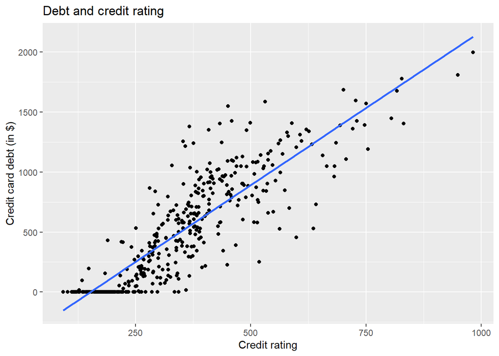

```r
# Scatter plot showing the relationship between Credit rating and Debt
ggplot(credit, aes(x = credit_rating, y = debt)) +
  geom_point() +
  labs(
    x = "Credit rating", y = "Credit card debt (in $)",
    title = "Debt and credit rating"
  ) +
  geom_smooth(method = "lm", se = FALSE)
```

## Debt and Age

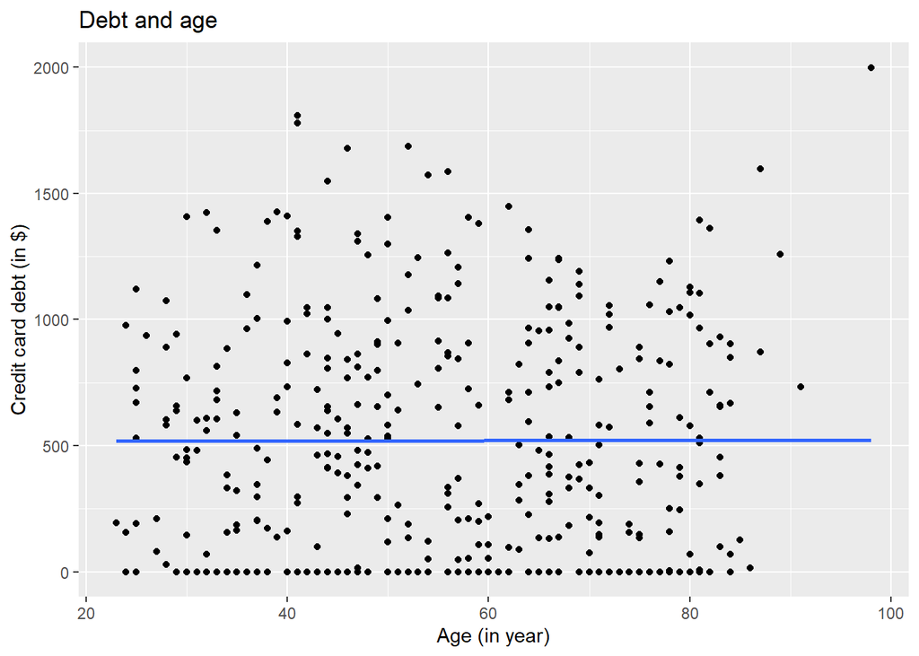

```r
# Scatter plot showing the relationship between Age and Debt
ggplot(credit, aes(x = age, y = debt)) +
  geom_point() +
  labs(
    x = "Age (in year)", y = "Credit card debt (in $)",
    title = "Debt and age"
  ) +
  geom_smooth(method = "lm", se = FALSE)
```

## (LC6.3)

Fit a new simple linear regression using lm(debt ~ credit_rating + age, data = credit_ch6) where credit_rating and age are the new numerical explanatory variables x1 and x2 . Get information about the “best-fitting” regression plane from the regression table by applying the get_regression_table() function. How do the regression results match up with the results from your previous exploratory data analysis?

```r
debt_model_2 <- lm(debt ~ credit_rating + age, data = credit)
get_regression_table(debt_model_2)
```

```
## # A tibble: 3 × 7
##   term          estimate std_error statistic p_value lower_ci upper_ci
##   <chr>            <dbl>     <dbl>     <dbl>   <dbl>    <dbl>    <dbl>
## 1 intercept      -270.      44.8       -6.02       0  -358.    -181.
## 2 credit_rating     2.59     0.074     34.8        0     2.45     2.74
## 3 age              -2.35     0.668     -3.52       0    -3.66    -1.04
```